# GDP and Smoking

[figure not shown]

#### By Rod Rahmjoo and Sepehr Tabaeizadeh

## Introduction and Motivation

Being Immigrants from a third world country, we have both seen our fair share of smokers. Since both of us are from Iran, we both know how prevalent the issue is there. We both have countless family and friends in Iran who are addicted to smoking. Since we now live in the United States, a first world country, we now know that this is not the case for everyone around the world. We hypothesized that country income (GDP) may play a major role when it comes to the number of smokers in any given country. In order to examine that hypothesis, and in order find out some of the root causes of smoking, we decided to do some more research in that area.

## Set Up

```python
import pandas as pd
import numpy as np
import math
import seaborn as sns
import matplotlib.pyplot as plt
import requests as reqs
import statsmodels.api as sm
from sklearn.linear_model import LinearRegression
from sklearn.model_selection import train_test_split
from sklearn import metrics as metrics
```

## Gathering Data

### Loading Data

This section is to download the csv files. This only needs to be run if the file do not exist in the directory of this program.

```python
sqlite_url = 'https://raw.githubusercontent.com/sepehrTabaeizadeh/FinalTutorial/main/somkers_gdp.csv'
page = reqs.get(sqlite_url, allow_redirects=True)
open('somkers_gdp.csv', 'wb').write(page.content)

sqlite_url = 'https://raw.githubusercontent.com/owid/co2-data/master/scripts/input/shared/continents.csv'
page = reqs.get(sqlite_url, allow_redirects=True)
open('continents.csv', 'wb').write(page.content)
```

```
17805
```

Now that we have our CSV files, lets load them in and take a look at what we are working with.

```python
data = pd.read_csv('somkers_gdp.csv')
data.head()
```

|  | Entity | Code | Year | Smoking prevalence, total (ages 15+) | GDP per capita, PPP (constant 2011 international $) | Continent |
| --- | --- | --- | --- | --- | --- | --- |
| 0 | Abkhazia | OWID_ABK | 2015 | NaN | NaN | Asia |
| 1 | Afghanistan | AFG | 2002 | NaN | 1063.635574 | NaN |
| 2 | Afghanistan | AFG | 2003 | NaN | 1099.194507 | NaN |
| 3 | Afghanistan | AFG | 2004 | NaN | 1062.249360 | NaN |
| 4 | Afghanistan | AFG | 2005 | NaN | 1136.123214 | NaN |

## Data Tidying

Now that we have loaded the **‘somkers_gdp.csv’** into the **'data'** table, we should now clean the input. By clean the input, I mean remove all rows that do not have a value for both GDP **and** Smoking Prevalence, because if both of these values are missing, the country does not give any useful input for smoking.

```python
data = data.loc[(data['Year'] >= 2000) & (data['Year'] <= 2016)]
#fix the naming because the naming convention is too long
data = data.rename(columns={'Smoking prevalence, total (ages 15+)': 'Smoking Prevalence', \
                     'GDP per capita, PPP (constant 2011 international $)': 'GDP'})

data = data.loc[data['Smoking Prevalence'].notna() | data['GDP'].notna()]
data = data.reset_index(drop = True)
data
```

|  | Entity | Code | Year | Smoking Prevalence | GDP | Continent |
| --- | --- | --- | --- | --- | --- | --- |
| 0 | Afghanistan | AFG | 2002 | NaN | 1063.635574 | NaN |
| 1 | Afghanistan | AFG | 2003 | NaN | 1099.194507 | NaN |
| 2 | Afghanistan | AFG | 2004 | NaN | 1062.249360 | NaN |
| 3 | Afghanistan | AFG | 2005 | NaN | 1136.123214 | NaN |
| 4 | Afghanistan | AFG | 2006 | NaN | 1161.124889 | NaN |
| ... | ... | ... | ... | ... | ... | ... |
| 4030 | Zimbabwe | ZWE | 2004 | NaN | 1785.608965 | NaN |
| 4031 | Zimbabwe | ZWE | 2006 | NaN | 1582.409117 | NaN |
| 4032 | Zimbabwe | ZWE | 2007 | NaN | 1501.078384 | NaN |
| 4033 | Zimbabwe | ZWE | 2008 | NaN | 1215.020416 | NaN |
| 4034 | Zimbabwe | ZWE | 2009 | NaN | 1336.212644 | NaN |

4035 rows × 6 columns

## Missing Data

Once we have tidied the input, now comes the time where we must fix the remaining missing data. First, we should check which columns have any missing values.

```python
numb_missing_Entity = data.size  - data.loc[data['Entity'].notna()].size
print(f'Number of Missing Entity Values: {numb_missing_Entity}')

numb_missing_Code = data.size  - data.loc[data['Code'].notna()].size
print(f'Number of Missing Code Values: {numb_missing_Code}')

numb_missing_Year = data.size  - data.loc[data['Year'].notna()].size
print(f'Number of Missing Code Values: {numb_missing_Year}')

print()
numb_missing_Continent = data.size  - data.loc[data['Continent'].notna()].size
print(f'Number of missing Continent Values: {numb_missing_Continent}')
print(f'Percentage of missing Continent values: {numb_missing_Continent*100/data.size}%')
print()

print(f'Total data size: {data.size}')
```

```
Number of Missing Entity Values: 0
Number of Missing Code Values: 4590
Number of Missing Code Values: 0

Number of missing Continent Values: 23058
Percentage of missing Continent values: 95.24163568773234%

Total data size: 24210
```

Since there are a large number of rows whose **‘Continent’** and **‘Code’** values are missing, we can import another dataset to help us fix the remaining missing values.

```python
continents = pd.read_csv('continents.csv')
continents
```

|  | Country | Code | Year | Region |
| --- | --- | --- | --- | --- |
| 0 | Abkhazia | OWID_ABK | 2015 | Asia |
| 1 | Afghanistan | AFG | 2015 | Asia |
| 2 | Akrotiri and Dhekelia | OWID_AKD | 2015 | Asia |
| 3 | Albania | ALB | 2015 | Europe |
| 4 | Algeria | DZA | 2015 | Africa |
| ... | ... | ... | ... | ... |
| 523 | Spain | NaN | 2015 | EU-28 |
| 524 | Sweden | NaN | 2015 | EU-28 |
| 525 | United Kingdom | NaN | 2015 | EU-28 |
| 526 | USSR | NaN | 2015 | Europe (excl. EU-28) |
| 527 | USSR | NaN | 2015 | Europe (excl. EU-28) |

528 rows × 4 columns

```python
numb_missing_Continent = continents.size  - continents.loc[continents['Region'].notna()].size
print(f'Number of missing Continent Values From New Dataset: {numb_missing_Continent}')
```

```
Number of missing Continent Values From New Dataset: 0
```

### Fixing the missing data

Now that we have both datasets, we should update the **'data'** list to get rid of as many missing values as possible. We can do this using the **'Entity'** column in the 'data' list since no row in the 'data' list has it's 'Entity' value missing. If we cannot find a match due to spelling differences, we can use the Code column if that column does not contain a missing value.

```python
#copy continent val from continent to data

#all rows where Continent is NA
for ind, row in data[data['Continent'].isna()].iterrows():
  Entity = row['Entity']

  helper_row = continents[continents['Country'] == Entity]
  helper_row = helper_row[helper_row['Region'].notna()]

  #check if string is NaN
  if helper_row.shape[0] > 0:
    #set code
    data.loc[ind, 'Continent'] = helper_row['Region'].iloc[0]
  else:

    Code = row['Code']

    second_help = continents[continents['Code'] == Code]
    second_help = second_help[second_help['Code'].notna()]

    if second_help.shape[0] > 0:
      data.loc[ind, 'Continent'] = second_help['Region'].iloc[0]
```

Since we will be using **'Entity'** and **'Code'** for the same purpose (as an identifier to communicate) and 'Entity' is the only one out of the two that does not have any missing values, we can ignore 'Code' and drop it's values.

```python
data = data.drop(columns='Code')
data
```

|  | Entity | Year | Smoking Prevalence | GDP | Continent |
| --- | --- | --- | --- | --- | --- |
| 0 | Afghanistan | 2002 | NaN | 1063.635574 | Asia |
| 1 | Afghanistan | 2003 | NaN | 1099.194507 | Asia |
| 2 | Afghanistan | 2004 | NaN | 1062.249360 | Asia |
| 3 | Afghanistan | 2005 | NaN | 1136.123214 | Asia |
| 4 | Afghanistan | 2006 | NaN | 1161.124889 | Asia |
| ... | ... | ... | ... | ... | ... |
| 4030 | Zimbabwe | 2004 | NaN | 1785.608965 | Africa |
| 4031 | Zimbabwe | 2006 | NaN | 1582.409117 | Africa |
| 4032 | Zimbabwe | 2007 | NaN | 1501.078384 | Africa |
| 4033 | Zimbabwe | 2008 | NaN | 1215.020416 | Africa |
| 4034 | Zimbabwe | 2009 | NaN | 1336.212644 | Africa |

4035 rows × 5 columns

Now, lets check to see how many missing **'Continent'** values we were able to recover by using the extra external dataset:

```python
numb_missing_Continent = data.size  - data.loc[data['Continent'].notna()].size
print(f'Number of missing Continent Values: {numb_missing_Continent}')
print(f'Percentage of missing Continent values: {numb_missing_Continent*100/data.size}%')
print()

print(f'Total data size: {data.size}')
```

```
Number of missing Continent Values: 3910
Percentage of missing Continent values: 19.380421313506815%

Total data size: 20175
```

### Summary of the Columns

- **Entity:** The country in which the data was collected.
- **Code:** Abbreviation of the country name (dropped).
- **Year:** The year in which the data was collected.
- **Smoking Prevalence:** Percentage of people above 15 who smoke in the given year and country.
- **GDP:** Gross Domestic Product of the country in the given year.
- **Continent:** The Region in which the country lays.

## Exploratory Data Analysis

Now that we have dealt with all the missing data and we have removed all the columns that we do not need. It is time to do some analyis on our data. Our goal is to find out if there is any correlation or relationship between the GDP of each country and the percentage of people above 15 who smoke.

### Smoking (Prevalence vs Year) and (GDP vs Year)

It is a good idea to create a graph of Smoking Prevalence vs Year. This will help us find out if there is any correlation between the year and smoking prevalence and also if there is any correlation between the year and GDP. This can help us later on with our ultimate goal which is to find out if there is any correlation between GDP and Smoking Prevalence.

To do this we are taking the mean of the Smoking prevalence among the countries in each year. This will help us to better visually analyse the data.

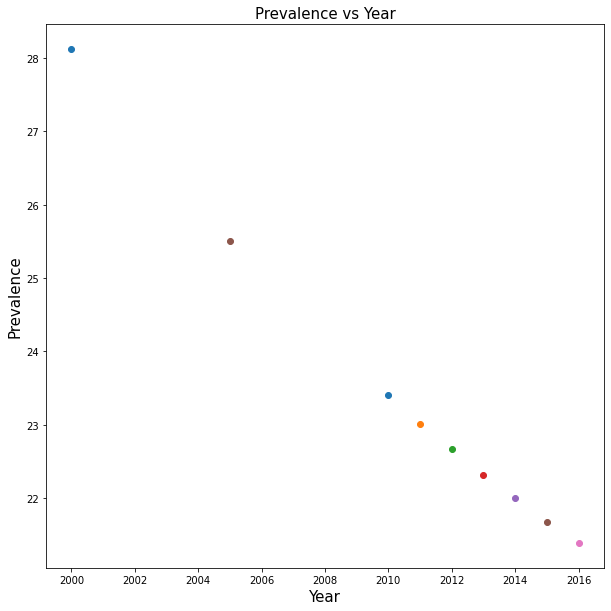

```python
plt.figure(figsize=(10,10))

for idx, row in data.groupby('Year'):

  plt.scatter(row['Year'].iloc[0],row['Smoking Prevalence'].mean())

plt.title('Prevalence vs Year', size = 15)
plt.xlabel('Year', size = 15)
plt.ylabel('Prevalence', size = 15)
#making plots more enjoyable
```

From the plot we can see that there is a decreasing trend between Smoking Prevalence and year, since as the year increases the Smoking Prevalence decreases. For next step it would be great to create a plot of mean GDP per year vs Year to see weather or not GDP follows the same downards trend as we saw above or if there is any type of visible relation between the two graphs.

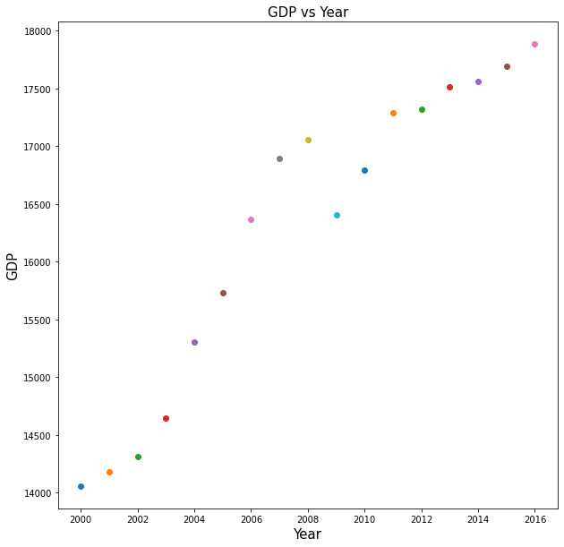

```python
plt.figure(figsize=(10,10))

for idx, row in data.groupby('Year'):

  plt.scatter(row['Year'].iloc[0],row['GDP'].mean())

plt.title('GDP vs Year',size=15)
plt.xlabel('Year', size= 15)
plt.ylabel('GDP', size = 15)
```

Although both GDP and Smoking Prevalence are correlated with Year it does not mean that they are correlated to eachother. But that does not mean that all of the work we did above is necissarily in vain. These two graphs have given us an overview that may help us later on.

### Smoking Prevalence vs Year

to better understand what kind of relationship lies between Smoking Prevalance and Year, we can plot the Smoking Prevalance vs Year graph and find the regression line.

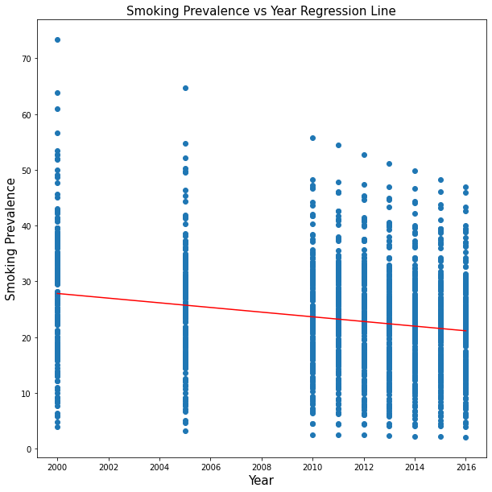

```python
plot_data = data
plot_data = plot_data.loc[pd.notna(plot_data['Year']) & pd.notna(plot_data['Smoking Prevalence'])]
plt.figure(figsize=(10,10))
plt.scatter(x = plot_data['Year'], y = plot_data['Smoking Prevalence'])
plt.title("Smoking Prevalence vs Year Regression Line", size = 15)
plt.xlabel('Year', size = 15)
plt.ylabel('Smoking Prevalence', size = 15)
x_plt = []
y_plt = []
for ind, row in plot_data.groupby('Year'):

  x_plt.append(row['Year'].iloc[0])
  y_plt.append(row['Smoking Prevalence'].mean())

m, b = np.polyfit(np.array(x_plt), np.array(y_plt), 1)
plt.plot(np.array(x_plt), m*np.array(x_plt)+b, color = 'red')
plt.show()
```

Now that we have the regression line, we can see that smoking in general decreases as the years increase. To make sure this regresion line is a good fit, we can take a look at the graph of the residuals.

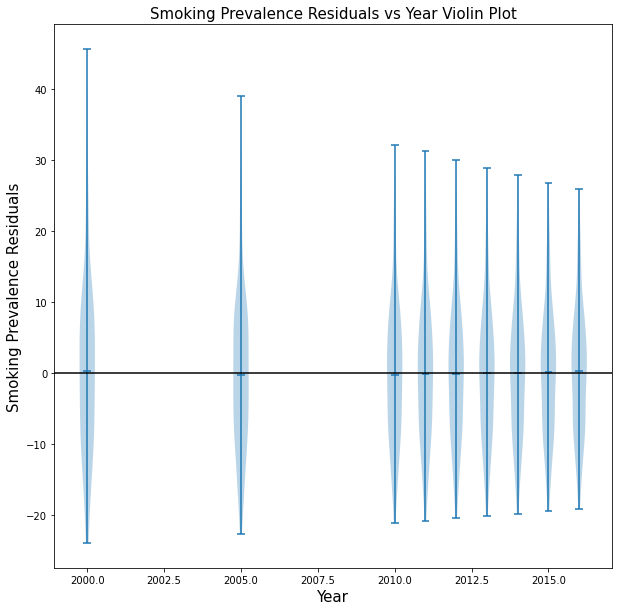

```python
temp = data
temp = temp[temp['Smoking Prevalence'].notna()]

X = np.array(temp['Year']).reshape(-1,1)
y = np.array(temp['Smoking Prevalence'])

lm = LinearRegression().fit(X, y)

residuals = []
residual_years = []

#go through each of the years
for ind, row in temp.groupby('Year'):

    #save the current year's value into the same position as where it's residuals will be in residuals list
    curr_year = row['Year'].iloc[0]
    residual_years.append(curr_year)

    #to save the list of residuals that we will then append to the residuals list
    curr_residuals = []
    #one prediction per year so we do not need this inside the other loop
    prediction = lm.predict(curr_year.reshape(-1,1))[0]

    for ind2, row2 in row.iterrows():
        #concat the residuals
        curr_residuals.append(row2['Smoking Prevalence'] - prediction)

    #add this residual list to the list of residuals
    residuals.append(curr_residuals)


fig, ax = plt.subplots(figsize=(10,10))
ax.violinplot(residuals,residual_years,showmeans=True)
ax.set_ylabel('Smoking Prevalence Residuals', fontsize=15)
ax.set_xlabel('Year', fontsize=15)
ax.set_title('Smoking Prevalence Residuals vs Year Violin Plot', fontsize=15)
#I have plotted the y = 0 line for convience
ax.axhline(y=0, color = 'black')
```

Since the residuals are well centered around 0 with the areas with the most amount of data being around 0, this means that the regression line is a good fit to our data. However, this does not mean that Smoking Prevalance only relies on the Year. We should check what kind of relationship lies between Smoking Prevalance and GDP as well.

### Smoking Prevalence vs GDP</h3

For the start we can plot Smoking prevalence vs GDP this will show us what to expect in our following analysis. Just having an idea of what to expect can help us to validate our results in the next steps.

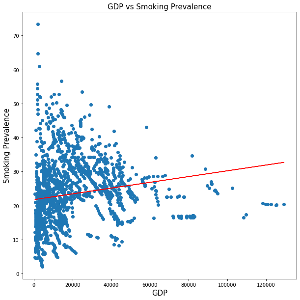

```python
plot_data = data
plot_data = plot_data.loc[pd.notna(plot_data['GDP']) & pd.notna(plot_data['Smoking Prevalence'])]
plt.figure(figsize=(10,10))
plt.scatter(x = plot_data['GDP'], y = plot_data['Smoking Prevalence'])
plt.title("GDP vs Smoking Prevalence", size = 15)
plt.xlabel('GDP', size = 15)
plt.ylabel('Smoking Prevalence', size = 15)
x_pos = plot_data['GDP']
m, b = np.polyfit(np.array(plot_data['GDP']), np.array(plot_data['Smoking Prevalence']), 1)
plt.plot(np.array(x_pos), m*np.array(x_pos)+b, color = 'red')
plt.show()
```

#### Smoking Prevalance vs GDP Range

Since the graph shown above is difficult to digest, lets fix that. We divide it into 4 subplots where each plot contains a subset of the years (ex: 2000-2004). Within these subplots, we can also draw the regression line associated with that subplot to see if the year makes a major difference in the predictions.

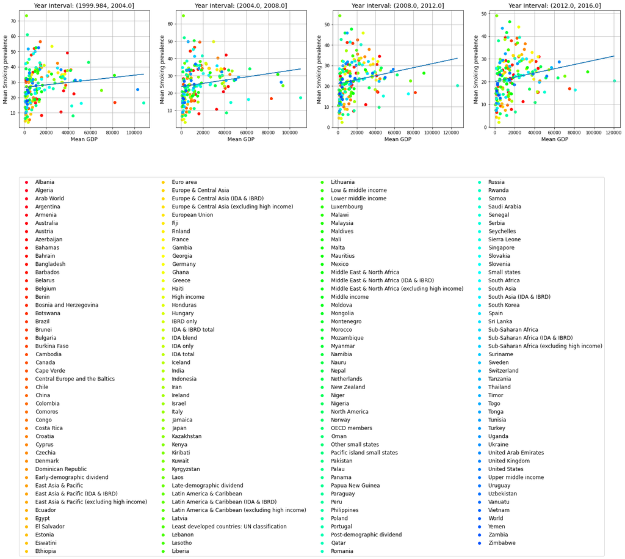

```python
plot_data = data
plot_data = plot_data.loc[pd.notna(plot_data['GDP']) & pd.notna(plot_data['Smoking Prevalence'])]
plot_data['periods'] = pd.cut(plot_data['Year'],4)
grouped_data = plot_data.groupby(['periods'])

fig, ax = plt.subplots(1,4,figsize=(25,5))

for (index, (idx, gp)) in enumerate(grouped_data):

    #x_pos and y_pos used for regression line
    x_pos = []
    y_pos = []

    cmap = plt.get_cmap('gist_rainbow')
    colors = [cmap(i) for i in range(0, 5000, 1)]
    ind = 0

    # Iterate through countries
    for idx2, gp2 in gp.groupby(['Entity']):
      # Append x_pos and y_pos by each countries GDP and Smoking Prevalence respectively.
      x = gp2['GDP'].mean()
      y = gp2['Smoking Prevalence'].mean()

      color = colors[ind]
      ind += 1


      x_pos.append(x)
      y_pos.append(y)
      # Add the points to the plot
      ax[index].scatter(x=x, y=y, label = gp2.iloc[0,0], color = color)

    ax[index].grid()
    # Set y label, x label and table title
    ax[index].set_ylabel('Mean Smoking prevalence', fontsize=12)
    ax[index].set_xlabel('Mean GDP', fontsize=12)
    ax[index].set_title(f'Year Interval: {idx}', fontsize=14)

    # Plot the regression line
    m, b = np.polyfit(np.array(x_pos), np.array(y_pos), 1)
    ax[index].plot(np.array(x_pos), m*np.array(x_pos)+b)
    #ax.legend(bbox_to_anchor=(1.05, 1.03), prop={'size': 12}, ncol = 3)
plt.legend(bbox_to_anchor=(.9, -0.4),prop={'size': 12}, ncol = 4)
plt.show()
```

We can see that as the years progress, the number of predicted smokers decrease (which is good because it fits with what we discovered previously in the **Smoking Prevalence vs Year** section). This can be visualized by examining the regression lines in each of the 4 subplots. For example, the first regression line is in the interval smoking prevelance ≈ [28, 36] whereas the fourth regression line is in the interval smoking prevelance ≈ [20, 30]. This means that overall smokers are decreasing as years increase.

### Smoking Prevalence Residuals vs GDP Range

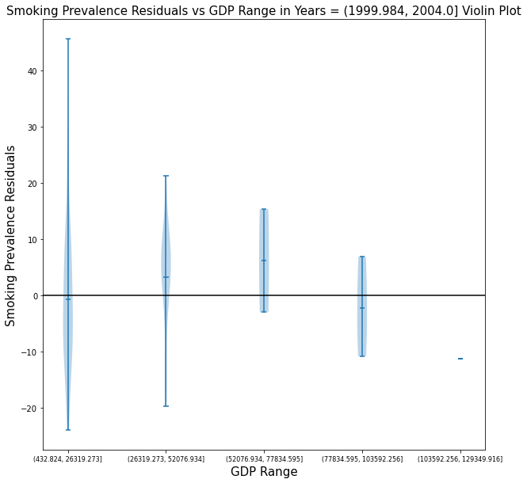

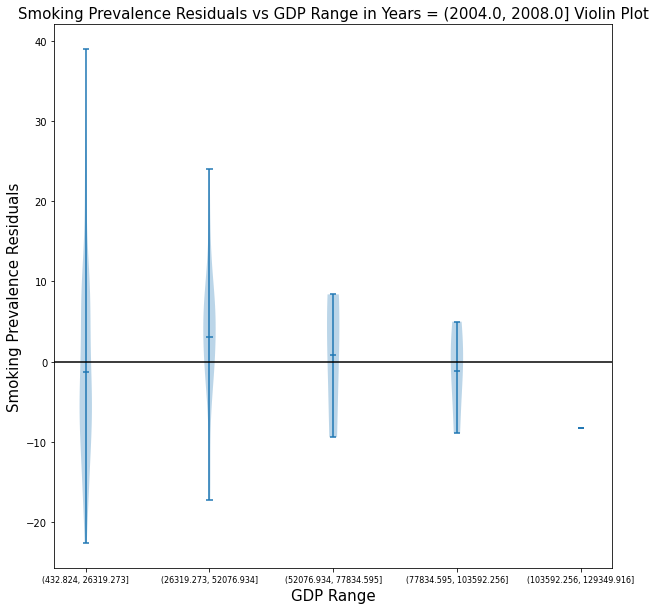

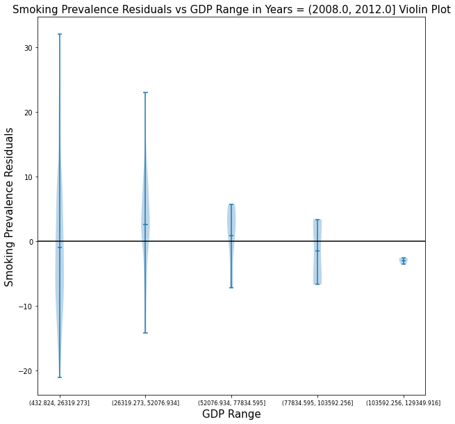

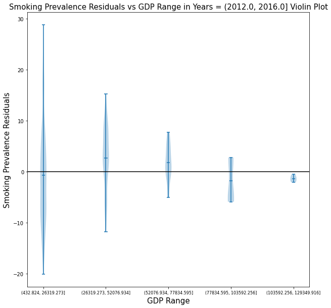

```python
gdp_data = plot_data
gdp_data['gdp_groups'] = pd.cut(gdp_data['GDP'],5)


for i, r in gdp_data.groupby('periods'):
    gdp_residuals = []
    smoking_prev = []

    period = r['periods'].iloc[0]

    for ind, row in r.groupby('gdp_groups'):

        curr_gdp = row['gdp_groups'].iloc[0]
        gdp_residuals.append(str(curr_gdp))

        curr_residuals = []

        for ind2, row2 in row.iterrows():

            year = np.array(row2['Year']).reshape(1,-1)
            prediction = lm.predict(year)
            curr_residuals.append(row2['Smoking Prevalence'] - prediction)

        smoking_prev.append(curr_residuals)


    fig, ax = plt.subplots(figsize=(10,10))

    ax.violinplot(smoking_prev, range(0,25,5), showmeans=True)


    ax.set_xticks(range(0,25,5))
    ax.set_xticklabels(gdp_residuals)

    ax.set_title(f'Smoking Prevalence Residuals vs GDP Range in Years = {period} Violin Plot', fontsize=15)
    ax.set_ylabel('Smoking Prevalence Residuals', fontsize=15)
    ax.set_xlabel('GDP Range', fontsize=15)
    #I have plotted the y = 0 line for convience
    ax.axhline(y=0, color = 'black')

    plt.xticks(fontsize = 8)
```

We can see that the data is not fully centered at 0 for all of the graphs for each of their respective GDP ranges. This means that we should take GDP into account when making our predictions as well. If we want to take both of these elements into account while making a prediction, we will need a multivariable linear regression instead. We can make sure that this is the case by combining all of these graphs into one.

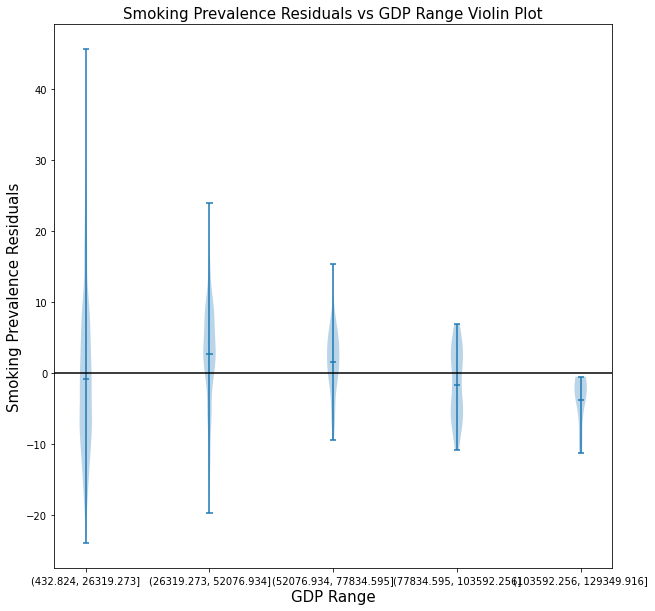

```python
gdp_data = temp
gdp_data['gdp_groups'] = pd.cut(gdp_data['GDP'],5)

gdp_residuals = []
smoking_prev = []

for ind, row in gdp_data.groupby('gdp_groups'):

    curr_gdp = row['gdp_groups'].iloc[0]
    gdp_residuals.append(str(curr_gdp))

    curr_residuals = []

    for ind2, row2 in row.iterrows():

        # gdp = np.array(row2['GDP']).reshape(-1,1)
        # prediction = lm.predict(gdp)[0]
        # curr_residuals.append(row2['Smoking Prevalence'] - prediction)

        year = np.array(row2['Year']).reshape(-1,1)
        prediction = lm.predict(year)
        curr_residuals.append(row2['Smoking Prevalence'] - prediction)

    smoking_prev.append(curr_residuals)


fig, ax = plt.subplots(figsize=(10,10))

ax.violinplot(smoking_prev, range(0,25,5), showmeans=True)


ax.set_xticks(range(0,25,5))
ax.set_xticklabels(gdp_residuals)

ax.set_title('Smoking Prevalence Residuals vs GDP Range Violin Plot', fontsize=15)
ax.set_ylabel('Smoking Prevalence Residuals', fontsize=15)
ax.set_xlabel('GDP Range', fontsize=15)
#I have plotted the y = 0 line for convience
ax.axhline(y=0, color = 'black')
```

As we predicted above, we may need to have a multivariable linear regression because even when we combine all of the graphs (all of the years into one graph), there are still areas that are not properly centered at 0 meaning that GDP may have some kind of interaction with Year.

## Smoking Prevalence vs. Year (grouped by GDP Range)

Now that we know there is some kind of correlation we should find out if there is an interactoin between GDP and Year. In other words we need to see if the coef of Smoking Prevalence vs Year differs in each GDP Group.

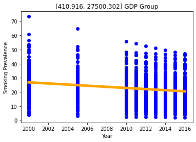

```
Coef: -0.398989834726404
```

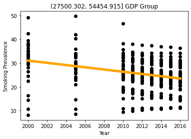

```
Coef: -0.469162684471035
```

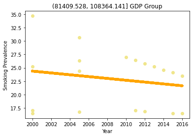

```
Coef: -0.1709647495361781
```

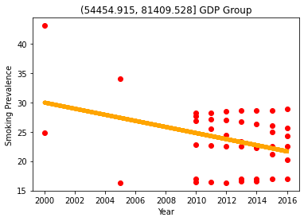

```
Coef: -0.5186809405467407
```

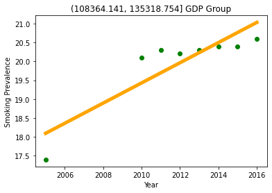

```
Coef: 0.2666666666666666
```

```python
# Cut the gdp columns into 5 different groups
# For each row add the corresponding interval to the gdp groups column

#####DO NOT CHANGE temp#####
temp = temp[temp['GDP'].notna()]
temp['gdp_groups'] = pd.cut(data['GDP'],5)

data_g = temp
data_g['gdp_groups'] = pd.cut(data['GDP'],5)

# Get name of all GDP Groups in our data
data_gdp_groups = data_g.gdp_groups.unique()
# Get all years in our data
data_years = data_g['Year'].unique()
# Colors to be used for each GDP plot
gdp_colors = ['blue','black','khaki','red','green']
i = 0

# Iterate through the gdp groups
for cont in data_gdp_groups:
    # Get all data related to the group cont
    cont_data = data_g.loc[data_g['gdp_groups'] == cont]
    # Set year column as independent variable
    x = cont_data['Year'].values.reshape(-1,1)
    # Set Smoking Prevalence as dependent variable
    y = cont_data['Smoking Prevalence'].values.reshape(-1,1)

    # Create a Linear regression model and train (fit a regression line)
    reg = LinearRegression().fit(x, y)
    # Add coef and variance and intercept to a variable
    coef = reg.coef_
    var =  reg.score(x, y)
    intercept = reg.intercept_

    # Plot each continent life expectency and year
    plt.scatter(x, y,  color = gdp_colors[i])
    plt.plot(x, reg.predict(x), color = 'orange', linewidth=5)
    plt.title("{} GDP Group".format(cont))
    plt.ylabel("Smoking Prevalence")
    plt.xlabel("Year")
    i += 1
    plt.show()
    print('Coef:', coef[0][0])
```

### Interaction Term and Multivariable Linear Model

```python
data = temp
# Cut the gdp columns into 5 different groups
# For each row add the corresponding interval to the gdp groups column
data['gdp_groups'] = pd.cut(data['GDP'],5)

#concat all the features we care about into a single var
base_features = data[['Year','Smoking Prevalence']]
dummy_features = pd.get_dummies(data.gdp_groups, drop_first = True)
features = pd.concat([base_features, dummy_features], axis = 1)

# continents = data.continent.values

#for all the gdp groups except the first dropped to avoid dummy var trap
for c in filter(lambda c: str(c) != '(432.824, 26319.273]', data.gdp_groups.values):
    #create new positions in features
    features['Year * '+str(c)] = features['Year'] * features[c]


#to train the linear regression
X = features.drop('Smoking Prevalence', axis = 1)
y = features['Smoking Prevalence']

# #linear regression
lm = LinearRegression().fit(X,y)

sm_mod = sm.OLS(y, sm.add_constant(X)).fit()
print(sm_mod.summary())
```

```
                            OLS Regression Results
==============================================================================
Dep. Variable:     Smoking Prevalence   R-squared:                       0.061
Model:                            OLS   Adj. R-squared:                  0.056
Method:                 Least Squares   F-statistic:                     11.81
Date:                Wed, 21 Jul 2021   Prob (F-statistic):           3.50e-18
Time:                        20:02:55   Log-Likelihood:                -6058.9
No. Observations:                1647   AIC:                         1.214e+04
Df Residuals:                    1637   BIC:                         1.219e+04
Df Model:                           9
Covariance Type:            nonrobust
===================================================================================================
                                      coef    std err          t      P>|t|      [0.025      0.975]
---------------------------------------------------------------------------------------------------
const                             826.2387    111.547      7.407      0.000     607.450    1045.028
Year                               -0.3997      0.055     -7.205      0.000      -0.509      -0.291
(26319.273, 52076.934]            113.1353    254.598      0.444      0.657    -386.237     612.507
(52076.934, 77834.595]            269.5782    753.223      0.358      0.720   -1207.804    1746.960
(77834.595, 103592.256]             5.6502    803.048      0.007      0.994   -1569.460    1580.760
(103592.256, 129349.916]        -1369.3946   1331.804     -1.028      0.304   -3981.614    1242.825
Year * (26319.273, 52076.934]      -0.0545      0.127     -0.430      0.667      -0.303       0.194
Year * (77834.595, 103592.256]     -0.0032      0.400     -0.008      0.994      -0.787       0.780
Year * (52076.934, 77834.595]      -0.1328      0.374     -0.355      0.723      -0.867       0.601
Year * (103592.256, 129349.916]     0.6796      0.662      1.026      0.305      -0.620       1.979
==============================================================================
Omnibus:                       87.094   Durbin-Watson:                   0.318
Prob(Omnibus):                  0.000   Jarque-Bera (JB):              106.790
Skew:                           0.529   Prob(JB):                     6.47e-24
Kurtosis:                       3.661   Cond. No.                     1.16e+07
==============================================================================

Warnings:
[1] Standard Errors assume that the covariance matrix of the errors is correctly specified.
[2] The condition number is large, 1.16e+07. This might indicate that there are
strong multicollinearity or other numerical problems.
```

From the data above we can see for each GDP_Group how much Smoking Prevalence increases per year:

```python
# Coef for year
coef_year = sm_mod.params[1]
# Coef for all continents (except Africa)
coef_continents = sm_mod.params[6:]
# Name of the continents in the same order as the data
conts_names = ['(26319.273, 52076.934]',' (77834.595, 103592.256]','(52076.934, 77834.595]','(103592.256, 129349.916]','(432.824, 26319.273]']

# (432.824, 26319.273] Coef
print('(432.824, 26319.273] :', coef_year)

i = 0
# Calculate and print coef for all contintnets
for cont_coef in coef_continents:
    print(conts_names[i],': ', (cont_coef+coef_year))
    i += 1
```

```
(432.824, 26319.273] : -0.39972577639731
(26319.273, 52076.934] :  -0.4542129971459177
 (77834.595, 103592.256] :  -0.4029436695692456
(52076.934, 77834.595] :  -0.5325160891039846
(103592.256, 129349.916] :  0.2798742138364516
```

# Interpreting the Result

As we can see in most of the GDP group as the GDP and year increases the Smoking Prevalence decreases except for the last group of countries which their GDP is between (103592.256, 129349.916]. This can have several reasons, for example one can be that there are less countries in that group therefore there is less data. Also it might be because countries with a very high GDP do not follow the same trend. This could be as a result of higher advertizing of tabbaco products (such as the JUUL in the United States).

## Multi Variable Linear Model's Residual Violin Plot

We think the plot fits our linear regression model because the plot is linear.

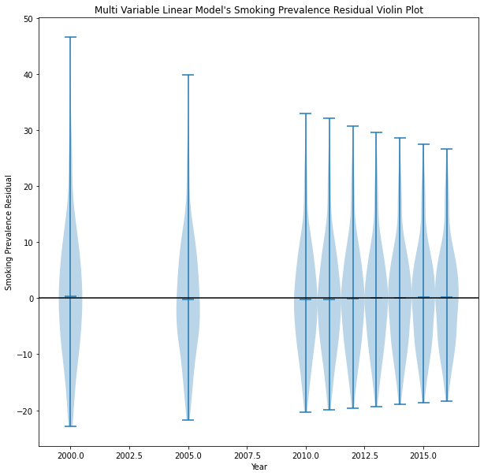

```python
i_residuals = []
i_residual_years = []

#for all of the year groupings
for ind, row in features.groupby('Year'):

    #to store the order of the years
    curr_year = row['Year'].iloc[0]
    i_residual_years.append(curr_year)

    #to add to residuals list later
    curr_residuals = []

    for ind2, row2 in row.iterrows():
        #make a prediction with all of the neccisiary parameters
        new_X = np.array(row2.drop('Smoking Prevalence'))
        prediction = lm.predict(new_X.reshape(1,-1))[0]
        #keep track of the residual
        curr_residuals.append(row2['Smoking Prevalence'] - prediction)

    #concat to the residuals lists
    i_residuals.append(curr_residuals)


#plot
fig, ax = plt.subplots(figsize=(10,10))

ax.violinplot(i_residuals,i_residual_years,widths=1,showmeans=True)

#I have plotted the y = 0 line for convience
ax.axhline(y=0, color = 'black')

ax.set_xlabel("Year")
ax.set_ylabel("Smoking Prevalence Residual")
ax.set_title("Multi Variable Linear Model's Smoking Prevalence Residual Violin Plot")
```

# Conclusion

Our analysis shows that Smoking Prevalence decreases as year increases. This result make sense because there are more researches now available about impact of smoking on human body and people became more aware about dangerousness of smoking. Also there are more restrictions on when and who can smoke now a days compared to before. Therefore, it makes a lot of sense that Smoking Prevalence decreases as the year increases.

After fitting a linear regression model for smoking prevalence including a term for an interaction between GDP and Year, we get the coefficient for each of the GDP groups. In other words we see by how many percentage smoking prevalence in in each GDP group changes. The result is as follow:

- (432.824, 26319.273] : -0.39972577639731
- (26319.273, 52076.934] : -0.4542129971459177
- (77834.595, 103592.256] : -0.4029436695692456
- (52076.934, 77834.595] : -0.5325160891039846
- (103592.256, 129349.916] : 0.2798742138364516

We both really enjoyed working on this final tutorial and things we discovered and learned in this journey. It was interesting to find out that Smoking Prevalence is correlated with both GDP and Year. We hope you enjoyed this tutorial as much as we enjoyed making it.